# Project 2: Biomedical & Clinical Informatics

# Make sure to check that your transform looks successful!

### 3.5.2 Centering & Scaling

Now that we have applied a Box-Cox transform to the target variable, we can center and scale the remainder of the variables. Note that we had to perform the Box-Cox prior to centering because the data has to be positive for a Box-Cox transformation (unless we switch to a [Yeo-Johnson transform](https://academic.oup.com/biomet/article-abstract/87/4/954/232908)). Centering will likely make a lot of the data negative, plus we know we have negatives in our dataset purposefully.

##### **Question 15**: [1 point]

Make a copy of the imputed training set, drop our original, non-Box-Cox transformed target from the dataset, and then center and scale the whole training set using the `scale()` function in R. I called my dataset `readyTrain`, so if you name it anything else just note you’ll have to update subsequent code. Then, **do the same thing for the test data**!

```r
# Box-Cox Transformation on imputedTrain data
bc_data <- BoxCoxTrans(imputedTrain$PredictedReadmissionRate)
imputedTrain$bc_PredictedReadmissionRate <- predict(bc_data, imputedTrain$PredictedReadmissionRate)

# Box-Cox Transformation on imputedTest data
bc_test_data <- BoxCoxTrans(imputedTest$PredictedReadmissionRate)
imputedTest$bc_PredictedReadmissionRate <- predict(bc_test_data, imputedTest$PredictedReadmissionRate)

# Create a copy of the imputed training set
readyTrain <- imputedTrain

# Drop the original, non-Box-Cox transformed target variable
readyTrain <- readyTrain %>%
  select(-PredictedReadmissionRate)

# Center and scale the training set
readyTrain_scaled <- as.data.frame(scale(readyTrain))

# Create a copy of the imputed test set
readyTest <- imputedTest

# Drop the original, non-Box-Cox transformed target variable
readyTest <- readyTest %>%
  select(-PredictedReadmissionRate)

# Center and scale the test set
readyTest_scaled <- as.data.frame(scale(readyTest))

# Print the first few rows of the scaled datasets
head(readyTrain_scaled)
```

```
##        MRSA Bacteremia Payment for pneumonia patients
## 010001       0.3789605                     0.47088288
## 010005       1.6374664                    -0.27441914
## 010006       1.0799005                     0.36641704
## 010007       0.4410096                     0.17938948
## 010011       0.2993082                     1.13418483
## 010012       0.2304687                    -0.03010386
##        Abdomen CT Use of Contrast Material Death rate for pneumonia patients
## 010001                          0.06279358                        -0.1080688
## 010005                          1.41360831                         1.9625893
## 010006                          0.97860017                         0.4779665
## 010007                         -0.55537588                         3.9941784
## 010011                         -0.02878708                         1.0249328
## 010012                          0.01700325                         1.4546920
##        Postoperative respiratory failure rate
```

[output cut: 125 more lines]

```r
head(readyTest_scaled)
```

```
##        MRSA Bacteremia Payment for pneumonia patients
## 010022      0.08117755                     -0.9012691
## 010033      0.52627291                      0.5377419
## 010045      0.29533281                     -0.4214015
## 010046      0.45146052                      1.7743920
## 010073      0.79024555                     -1.5272862
## 010083     -1.59341147                     -1.2840981
##        Abdomen CT Use of Contrast Material Death rate for pneumonia patients
## 010022                          -1.3136937                       -0.64840339
## 010033                           2.4999606                       -1.26119629
## 010045                          -0.1093818                        0.09570226
## 010046                          -0.8118971                       -0.69217431
## 010073                          -1.1380649                        1.71522634
## 010083                          -0.1344717                        0.79603700
##        Postoperative respiratory failure rate
```

[output cut: 125 more lines]

```r
## Make sure you both center AND scale your data!
```

If you’re worried you did it incorrectly, or you got stuck, you may load my dataset to proceed.

**Hint**: Make sure to turn your centered, scaled **matrix** back into a dataframe! By default, it creates a matrix.

```r
load(file = "readyTrain.Rdata")
readyTrain <- readyTrain %>% data.frame()

load(file = "readyTest.Rdata")
readyTest <- readyTest %>% data.frame()
```

# 4 Unsupervised Learning Methods

## 4.1 Principal Component Analysis

It’s our friend, PCA again! We are going to leverage unsupervised learning methods, namely Principal Component Analysis and $k$-means clustering, to help us to further reduce the dimensionality of our dataset. The other advantage of this type of analysis is segmentation: it will allow us to determine if there are broader classifications of our hospitals that we need to report back to the advocacy group.

Let’s apply the PCA and display the scree plot of the first 15 principal components.

```r
pca <- prcomp(readyTrain)
summary(pca)
```

```
## Importance of components:
##                          PC1     PC2     PC3     PC4     PC5     PC6     PC7
## Standard deviation     2.951 1.76558 1.56187 1.47712 1.30130 1.24633 1.18033
## Proportion of Variance 0.256 0.09168 0.07175 0.06417 0.04981 0.04569 0.04098
## Cumulative Proportion  0.256 0.34773 0.41948 0.48366 0.53346 0.57915 0.62012
##                           PC8     PC9    PC10    PC11    PC12    PC13   PC14
## Standard deviation     1.1411 1.04598 0.98838 0.94663 0.92540 0.90551 0.8746
## Proportion of Variance 0.0383 0.03218 0.02873 0.02636 0.02519 0.02412 0.0225
## Cumulative Proportion  0.6584 0.69060 0.71933 0.74569 0.77088 0.79499 0.8175
##                           PC15    PC16    PC17    PC18    PC19    PC20    PC21
## Standard deviation     0.77922 0.76403 0.75386 0.70783 0.69926 0.66470 0.61676
## Proportion of Variance 0.01786 0.01717 0.01671 0.01474 0.01438 0.01299 0.01119
## Cumulative Proportion  0.83535 0.85252 0.86923 0.88397 0.89835 0.91134 0.92253
##                           PC22    PC23    PC24    PC25    PC26    PC27   PC28
## Standard deviation     0.59823 0.57663 0.52832 0.49980 0.49838 0.48923 0.4664
## Proportion of Variance 0.01053 0.00978 0.00821 0.00735 0.00731 0.00704 0.0064
## Cumulative Proportion  0.93306 0.94284 0.95105 0.95839 0.96570 0.97274 0.9791
##                           PC29    PC30    PC31    PC32    PC33    PC34
## Standard deviation     0.41727 0.40916 0.38864 0.31460 0.30263 0.16190
## Proportion of Variance 0.00512 0.00492 0.00444 0.00291 0.00269 0.00077
## Cumulative Proportion  0.98426 0.98918 0.99362 0.99654 0.99923 1.00000
```

Let’s also look at this as a Scree Plot.

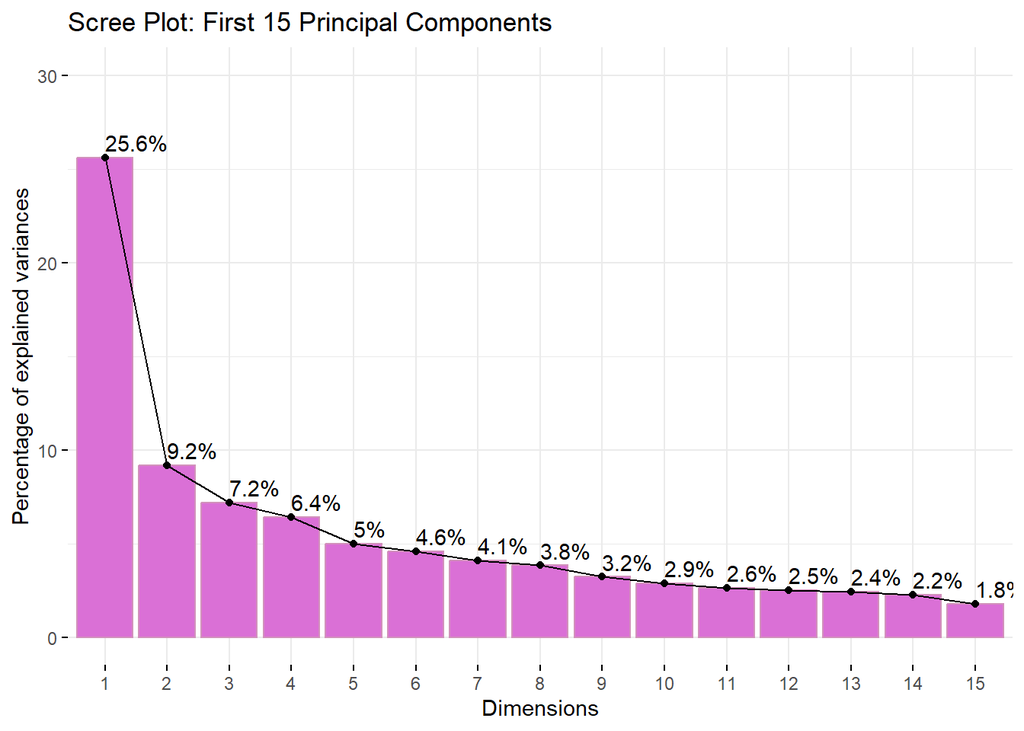

##### **Question 16**: [1 point]

Using the ‘elbow’ method of the scree plot - the point at which the percentage of variance explained seems to level off - approximately how many principal components would be significant to explain the total variation in the training data set? (**Hint**: if it’s not super obvious, that’s actually informative!)

> Your answer here the elbow looks like is around dimession 6

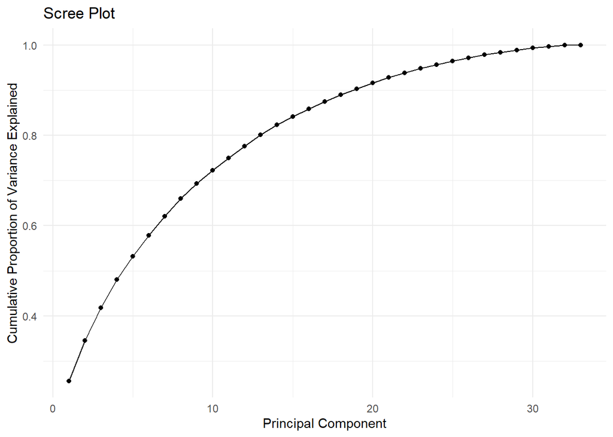

```r
# Perform PCA on the scaled training dataset
pca_result <- prcomp(readyTrain[, -ncol(readyTrain)], center = TRUE, scale. = TRUE)

# Calculate the variance explained by each principal component
explained_variance <- pca_result$sdev^2 / sum(pca_result$sdev^2)

# Create a scree plot
scree_plot <- qplot(1:length(explained_variance), cumsum(explained_variance), geom = "line") +
  geom_point() +
  xlab("Principal Component") +
  ylab("Cumulative Proportion of Variance Explained") +
  ggtitle("Scree Plot") +
  theme_minimal()
# Display the scree plot
print(scree_plot)
```

Perform PCA: Using the prcomp function on the scaled training dataset, excluding the target variable. Calculate Explained Variance: Compute the proportion of variance explained by each principal component. Plot Scree Plot: Plot the cumulative proportion of variance explained by each principal component to visualize the ‘elbow’. Run this code in your R environment to generate the scree plot. The point at which the line starts to level off indicates the optimal number of principal components to retain.

Elbow Point: The number of principal components at which the cumulative proportion of variance explained starts to level off is considered optimal. This indicates the number of components that capture most of the variation in the data.

Next, let’s explore how much the variables are contributing (this is based on the weight of their rotations). In PCA, we are interested in the **loadings**, i.e., the linear combination weights (coefficients) whereby unit-scaled components define or “load” a variable. Loadings help us interpret principal components.

You may have noticed we used the `prcomp()` function above; `prcomp()` will return the loadings in the variable `$rotation`, which contains a matrix of variable loadings. These loadings have been determined from the eigenvectors, which without getting into what that is (because we’d have to take a departure into linear algebra), suffice it to say that they are how we are measuring the direction and magnitude during each subsequent rotation of the principal components as we measure the variance explained.

Additionally, we are going to color this by our group variable in the dataset, `ComparedToNational_Hospital.return.days.for.pneumonia.patients`. Recall that when we explored this earlier this variable shows, relative to the national average, the performance of each hospital in terms of its pneumonia-related return-to-hospital days, where “Worse” is worse than the national average, so that hospital has a lot of patients returning with pneumonia and/or for a large number of days.

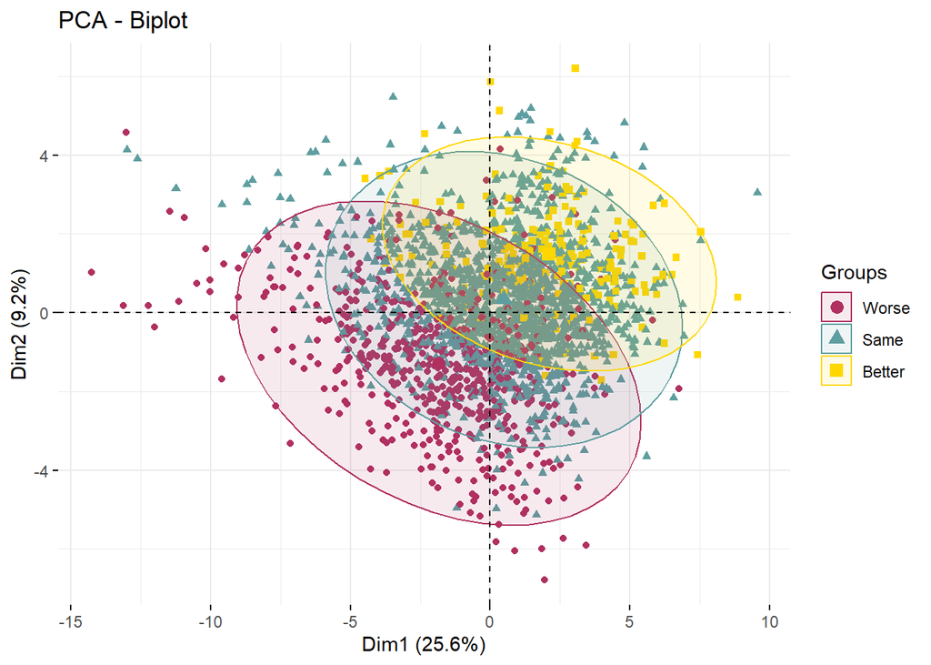

##### **Question 17**: [1 point]

On principal components 1 and 2 (the PCs that account for the **most** variance in the training data), do you see any pattern (i.e., clustering) relative to the hospital return days for pneumonia patients compared to the national average? Why or why not?

> this indicates that there are underlying patterns in the data that are captured by the first two principal components. There is clustering relative to the hospital return days for pneumonia patients

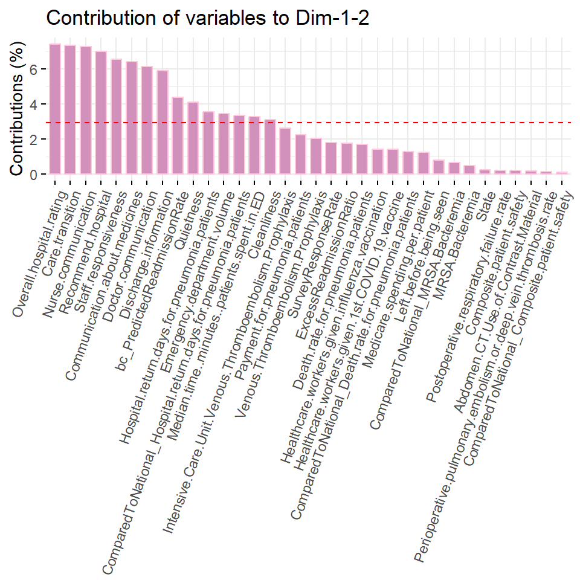

**Notice** that ALL of the top variables are based on patient survey ratings! We also see our target, `PredictedReasmissionRate`, among the significant variables.

## 4.2 *k*-means Clustering

$k$-means is a centroid-based clustering algorithm, where a “centroid” is the geometric center of an object often measured by Euclidean distance. In the algorithm, the distance between each data point and a centroid is calculated by randomly grabbing data; these distances are then used to assign the data point to a cluster. The goal is to identify the optimal $k$ number of groups in a dataset by minimizing the distance of each datapoint to a respective centroid.

Although multiple methods exist to determine the optimal number of clusters, one commonly employed is **heuristic**, i.e., it isn’t really computational. You will either choose the optimal clusters based on a set of options of $k$ graphically or you can once again employ the ‘elbow’ method. Let’s start by visually inspecting the effect of different $k$ clusters on PC1 and PC2 of the dataset:

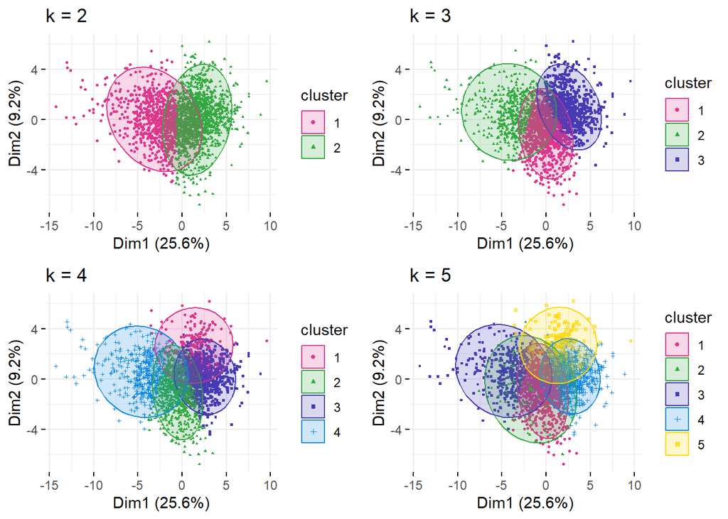

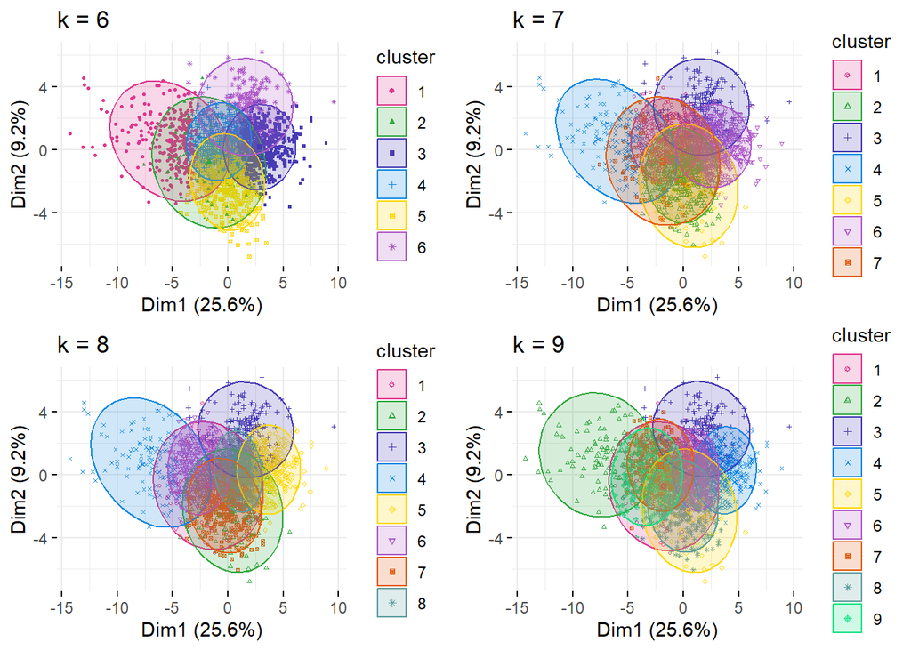

##### **Question 18**: [1 point]

Which number of clusters, $k$, do you think has the best explanatory power? Is it hard to tell? it is hard to tell > Your answer here K 8 and K 6

Next, let’s employ the ‘elbow’ method again, this time to look at when the **within sum of squares** drops off rather than the percent variance, as was done in PCA.

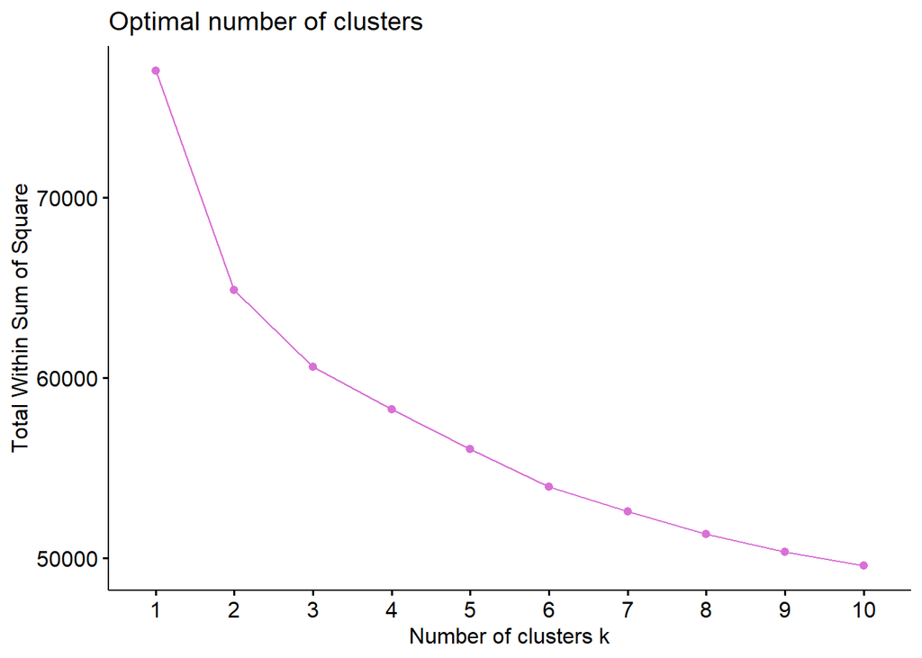

#### **Question 19**: [1 point]

What is the **within sum of squares** and what exactly is it measuring here? By the elbow method, which $k$ is the optimal number of clusters? Did it agree with your choice from the other heuristic method?

> your anwser here The within sum of squares (WSS) measures the compactness of clusters in a clustering algorithm like k-means. It is the sum of squared distances between each point and its cluster centroid. Lower WSS values indicate more compact clusters.

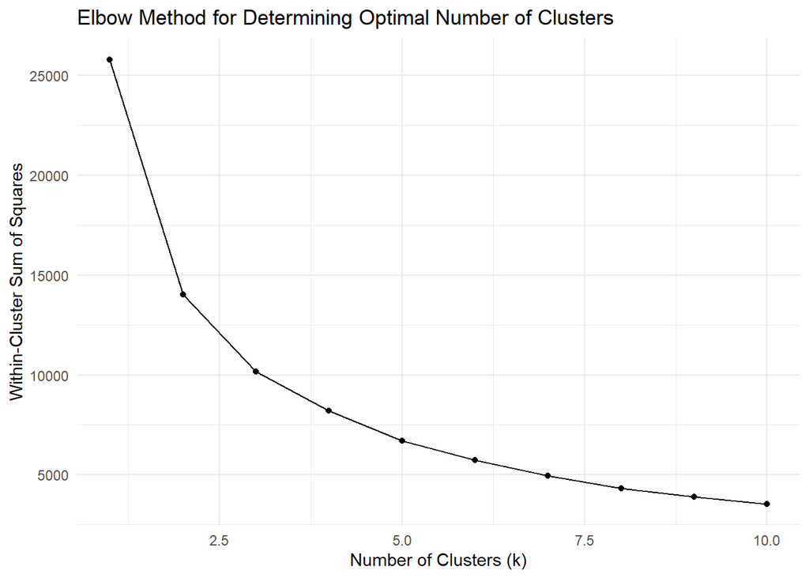

```r
# Extract the first two principal components
pca_data <- as.data.frame(pca_result$x[, 1:2])
pca_data$ExcessReadmissionRatio <- readyTrain$ExcessReadmissionRatio

# Calculate WCSS for different values of k
set.seed(123)
wcss <- sapply(1:10, function(k) {
  kmeans(pca_data[, 1:2], centers = k, nstart = 20)$tot.withinss
})

# Plot the WCSS against the number of clusters
elbow_plot <- qplot(1:10, wcss, geom = "line") +
  geom_point() +
  xlab("Number of Clusters (k)") +
  ylab("Within-Cluster Sum of Squares") +
  ggtitle("Elbow Method for Determining Optimal Number of Clusters") +
  theme_minimal()

# Display the elbow plot
print(elbow_plot)
```

## 4.3 Segmentation Analysis

As we said before, the goal of segmentation analysis is to broadly cluster our hospitals by their features to help us characterize them.

#### **Question 20**: [1 point]

Let’s explore the clusters - segments - of the hospitals based on their average values from the **original** dataset. Your task is to add comments to this code chunk.

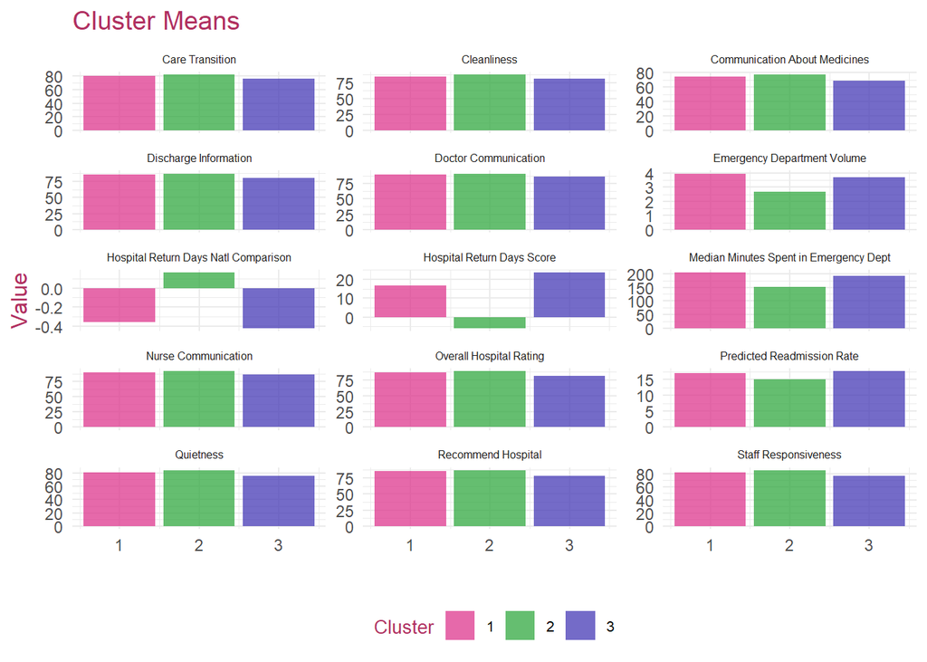

```r
# Perform k-means clustering on the readyTrain dataset
kmeansResult <- kmeans(readyTrain,
                         centers = 3,            # Specifies 3 clusters for k-means clustering
                         nstart = 50,            # Number of initial sets of cluster centers to try
                         iter.max = 1000,        # Maximum number of iterations
                         algorithm = "MacQueen") # Algorithm used for clustering

# Add a column called Cluster to the imputedTrain dataset based on the clustering result
kmeansTrain <- imputedTrain %>%
  mutate(Cluster = kmeansResult$cluster) %>%
  clean_names() # Clean the column names
# Specify which variables to import for PCA
pcaImportantVars <- c("overall_hospital_rating",
                      "care_transition",
                      "nurse_communication",
                      "recommend_hospital",
                      "staff_responsiveness",
                      "communication_about_medicines",
                      "doctor_communication",
                      "discharge_information",
                      "predicted_readmission_rate",
                      "quietness",
                      "median_time_minutes_patients_spent_in_ed",
                      "hospital_return_days_for_pneumonia_patients",
                      "emergency_department_volume",
                      "compared_to_national_hospital_return_days_for_pneumonia_patients",
                      "cleanliness")

# Rename some of the rows in the Cluster column
kmeansTrain %>%
  # Select relevant variables and 'Cluster' column
  select(all_of(pcaImportantVars), cluster) %>%
  rename(`Hospital Return Days Score` = hospital_return_days_for_pneumonia_patients,
         `Hospital Return Days Nat'l Comparison` = compared_to_national_hospital_return_days_for_pneumonia_patients,
         `Median Minutes spent in Emergency Dept` = median_time_minutes_patients_spent_in_ed) %>%
  # Clean column names with title case
  clean_names(case = "title") %>%
  # Group data by cluster
  group_by(Cluster) %>%
  # Summarize numeric variables by calculating the mean, removing NAs
  summarise_if(is.numeric, mean, na.rm = TRUE) %>%
  # Reshape data for plotting
  pivot_longer(-1, names_to = "Measure", values_to = "Value") %>%
  # Create a plot with the given data
  ggplot(aes(x = Cluster, y = Value, fill = as.factor(Cluster))) +
    geom_col(alpha = 0.75) +
    # Set custom colors for clusters
    scale_fill_manual(values = myPal) +
    # Add titles and labels
    labs(title = "Cluster Means",
         x = "",
         fill = "Cluster") +
    # Use a minimal theme
    theme_minimal() +
    # Customize legend and title appearance
    theme(legend.position = "bottom",
          strip.text = element_text(size=6),
          legend.text = element_text(size = 8),
          legend.title = element_text(size = 10),
          title = element_text(size = 12, color = "maroon")) +
    # Create facets for each measure with free y-axis scaling
    facet_wrap(~Measure,
               scales = "free_y",
               ncol = 3)
```

#### **Question 21**: [1 point]

## Ryan C

Notice, for example, that Cluster 2 hospitals seem to include the hospitals that had the **below** national average return hospital days (and thus the fewest return hospital days in terms of the quantitative score). Look at how else you might broadly characterize - or segment - these hospitals.

Then come up with at least FOUR characteristics per cluster. You may choose to focus on different attributes for different clusters. Fill in the code for the table below. I start you out with two examples for Cluster 1, but feel free to add more! You are also welcome to rename Cluster 1 if you think of a catchier name than I chose!

Table 5. Hospital segmentation analysis: three types of broad groupings identified.

[output not shown]

## 4.4 Final Remarks on Segmentation

We don’t technically have to stop our segmentation analysis here, but we will so that we can focus on other analyses. One thing we might choose to do in the future, for example, is to choose a classification machine learning algorithm to test the predictions based on these three clusters.

#### **Question 22**: [1 point]

## Ryan C

Make a recommendation for our client for 1-2 machine learning analyses **your team** would choose to use to test whether these clusters can be used for robust predictions of hospital performance for pneumonia patients. How would you know whether or not your predictions were robust? What would you look for or compare?

> I would recommend a logistic regression to test and see if the clusters can predict pneumonia outcomes accurately based on the given historical data. Then, I’d preform a decision tree analysis to try and understand the factors that influence the predictions made by those clusters. To check if predictions are robust, I’d just compare the predicted outcomes with actual outcomes from a new set of pneumonia patient data, and check different metricslike accuracy, sensitivity, and specificity. If the model consistently predicts outcomes across different datasets, it indicates robustness.

# 4 Supervised Learning Methods

We are going to perform two supervised learning methods: an Ordinary Least Squares (OLS) regression followed by an Elastic Net. However, before we do our OLS regression, we need to assess multicollinearity. Recall from lecture that multicollinearity is when one or more of our predictors are moderately to highly correlated with each other. This can **inflate our coefficients** and thereby cause spurious associations through **false positives** (i.e., small p-values when we don’t actually have them!).

#### **Question 23**: [1 point]

## Ryan C

Could our PCA benefit from re-running it after dealing with possible multicollinearity? Explain your reasoning.

> Yes, re-running PCA after addressing any possible multicollinearity problems woudl benefit the analysis. By addressing any multicollinearity, it would increase the variance of the principal components. This would hopefully make stronger components that wouldnt be dominated by only a few variables.

## 4.1 Multicollinearity Assessment

There are two primary ways we assess multicollinearity, which we will implement here. The first is pairwise correlation, usually through a Pearson or Spearman correlation, and the other is by checking the variance inflation attributable to the features. Although it is not always necessary to check for multicollinearity it can be helpful to understand the underlying ‘landscape’ of your features and their relationship to both the target and to each other. For the types of analyses we plan to undertake, it’s a very necessary assessment to run.

## 4.1 Pairwise Correlation

Let’s make a correlation matrix and look at the correlation of the variables within the training dataset to assess possible areas of multicollinearity.

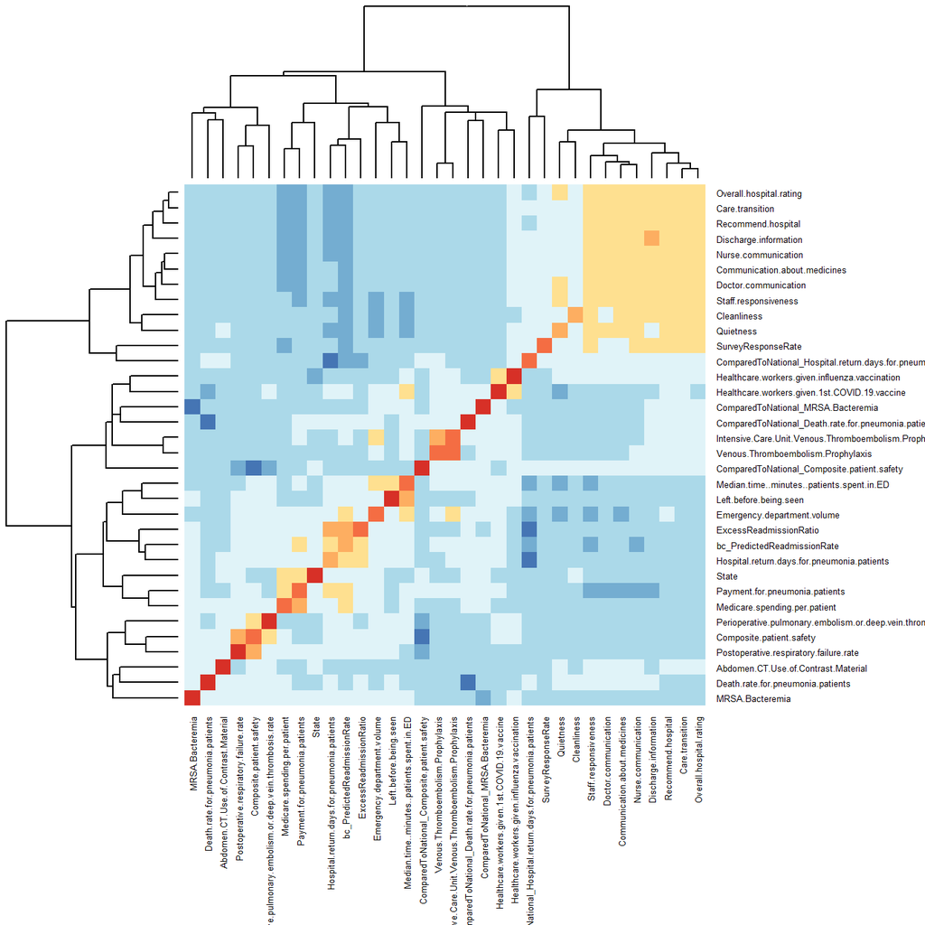

##### **Question 24**: [1 point]

## Ryan C

Where do you see the highest potential for multicollinearity? Why do you say that?

> The highest potential for multicollinearity would be in the top right of the heat map which would be all the variables about communication, ratings, information, and the state of the hospital (cleanliness, quietness).

## 4.2 OLS Multiple Linear Regression

### 4.2.1 Fitting a model to estimate VIF

Another way we can assess multicollinearity is by fitting a multiple linear regression and estimating the **variance inflation factors**, or VIF, which estimates how much the variance of an estimated regression coefficient increases if your predictors are correlated. Specifically, variance inflation can identify **multicollinearity** when the VIF is greater than 4 and especially when it is above 10.

Fit a linear regression with the training data, using the Box-Cox transformed `Predicted Readmission Rate` as the target. The four plots are diagnostic plots for the primary assumptions of a linear regression: linearity between the outcome and the predictors, normally distributed residuals, homosecadasticity or equality of variances in the residuals, and no outliers or high leverage/influence points.

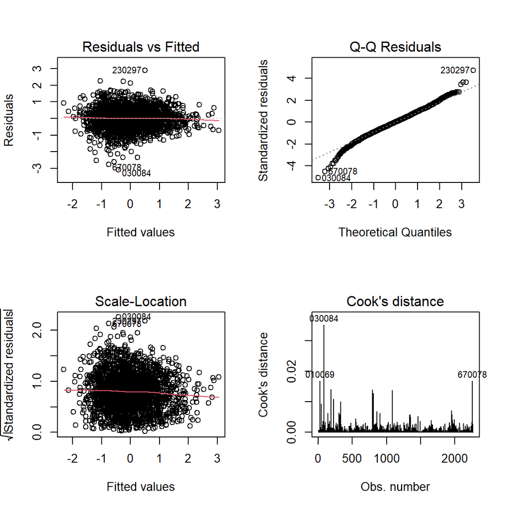

##### **Question 25**: [1 point]

## Ryan C

You may have to do a little outside research, but interpret the four plots that have come off the regression. Do we largely meet the assumptions for an OLS multiple regression? Why or why not?

**Note:** If you are not entirely sure about the Q-Q plot, you can run a Shapiro-Wilk test on the residuals using the following code:

```r
shapiro.test(residuals(mod))
```

```
##
##  Shapiro-Wilk normality test
##
## data:  residuals(mod)
## W = 0.99204, p-value = 0.0000000008371
```

### 4.2.2 Estimating the VIF (Variance Inflation Factors)

Next, let’s calculate the VIFs using the `vif()` function that is part of the `car` package. Note that I am not printing all of the VIFs, just the top 15 after sorting in descending order.

Table 6. Variance Inflation Factors after multiple linear regression

|  | VIF |
| --- | --- |
| Overall.hospital.rating | 24.65 |
| Recommend.hospital | 16.39 |
| Nurse.communication | 8.57 |
| Care.transition | 8.32 |
| Staff.responsiveness | 5.65 |
| Communication.about.medicines | 4.79 |
| Doctor.communication | 4.28 |
| Discharge.information | 3.58 |
| Hospital.return.days.for.pneumonia.patients | 3.57 |
| Intensive.Care.Unit.Venous.Thromboembolism.Prophylaxis | 3.37 |
| ComparedToNational_Hospital.return.days.for.pneumonia.patients | 3.27 |
| Venous.Thromboembolism.Prophylaxis | 3.19 |
| Composite.patient.safety | 2.73 |
| Quietness | 2.37 |
| Median.time..minutes..patients.spent.in.ED | 1.97 |

##### **Question 26**: [1 point]

## Ryan C

Does multicollinearity seem to be an issue in this dataset and, if so, among which variables? Why do you come to this conclusion?

> After reading this article https://corporatefinanceinstitute.com/resources/data-science/variance-inflation-factor-vif/#:~:text=Generally%2C%20a%20VIF%20above%204,that%20needs%20to%20be%20corrected. I found that multiple variables have high multicollinearity mainly all the varaibles above 5 have strong multicollinearity so tese 5 need to be addressed Overall.hospital.rating 24.65 Recommend.hospital 16.39 Nurse.communication 8.57 Care.transition 8.32 Staff.responsiveness 5.65.

### 4.2.3 Dropping the most collinear variables and re-running the OLS regression.

Even though we plan to proceed with an elastic net (which is much more robust to multicollinearity), to finish our OLS regression we will need to drop the most collinear variables. Note that I am **making a copy** of `readyTrain` first, called `regressionTrain`. We will do the same for `readyTest` also.

```r
## Drop those with VIF over 4
regressionTrain <- readyTrain %>%
  select(-Overall.hospital.rating, -Recommend.hospital, -Nurse.communication, -Care.transition, -Staff.responsiveness, -Communication.about.medicines, -Doctor.communication)

## Do the same for the testing data!
regressionTest <- readyTest %>%
  select(-Overall.hospital.rating, -Recommend.hospital, -Nurse.communication, -Care.transition, -Staff.responsiveness, -Communication.about.medicines, -Doctor.communication)
```

Now, re-run the linear regression and let’s print the adjusted $R^2$.

```
## [1] 0.6076983
```

It is a surprisingly high for how many features it has! (although it isn’t stellar, granted)

Use the `step()` function to do a backward regression to find our **most parsimonious** model. Stepwise regression drop terms that are not significant or important, thereby only keeping the features that contribute to the overall explanation of variance in predicted readmission rate.

```r
## Perform a backward, stepwise regression to find the most parsimonious model
bestMod <- step(mod,
            direction = "backward",
            trace = FALSE)
```

Lastly, let’s take a peek at the results. We will use a package called `stargazer` to help us visualize the results in a nicely organized way.

```r
## Print a table using stargazer
stargazer(bestMod,
          type = "html",
          title = "Table 7. Parsimonious OLS Regression Results.")
```

**Table 7. Parsimonious OLS Regression Results.**

|  | *Dependent variable:* |
| --- | --- |
|  | bc_PredictedReadmissionRate |
| MRSA.Bacteremia | 0.049*** |
|  | (0.014) |
| Payment.for.pneumonia.patients | 0.229*** |
|  | (0.017) |
| Abdomen.CT.Use.of.Contrast.Material | 0.028** |
|  | (0.013) |
| Death.rate.for.pneumonia.patients | -0.126*** |
|  | (0.014) |
| Postoperative.respiratory.failure.rate | 0.023* |
|  | (0.013) |
| Medicare.spending.per.patient | 0.042** |
|  | (0.017) |
| Median.time..minutes..patients.spent.in.ED | 0.112*** |
|  | (0.015) |
| Intensive.Care.Unit.Venous.Thromboembolism.Prophylaxis | 0.060*** |
|  | (0.015) |
| Hospital.return.days.for.pneumonia.patients | 0.088*** |
|  | (0.018) |
| Cleanliness | -0.044*** |
|  | (0.015) |
| Quietness | -0.094*** |
|  | (0.016) |
| ExcessReadmissionRatio | 0.462*** |
|  | (0.017) |
| SurveyResponseRate | -0.029** |
|  | (0.014) |
| Emergency.department.volume | 0.091*** |
|  | (0.016) |
| State | 0.039*** |
|  | (0.014) |
| Constant | 0.000 |
|  | (0.013) |
| Observations | 2,266 |
| R<sup>2</sup> | 0.611 |
| Adjusted R<sup>2</sup> | 0.608 |
| Residual Std. Error | 0.626 (df = 2250) |
| F Statistic | 235.316*** (df = 15; 2250) |
| *Note:* | p<0.1; p<0.05; p<0.01 |

Lastly, let’s assess how **good a predictive model** our OLS regression model is. We will use the `predict()` function to first fit our most parsimonious model `bestMod` to the test data:

```r
## Make the predictions
predictions <- predict(bestMod, newdata = regressionTest)
## Calculate the RMSE
RMSE(predictions, regressionTest$bc_PredictedReadmissionRate)
```

```
## [1] 0.6635444
```

```r
maxvalues <- max(readyTrain$bc_PredictedReadmissionRate)
maxvalues
```

```
## [1] 3.518718
```

```r
minvalues <- min(readyTrain$bc_PredictedReadmissionRate)
minvalues
```

```
## [1] -3.703643
```

##### **Question 27**: [1 point]

## Ryan C

Can you interpret what the RMSE tells your client here? Is this a good model? An okay model?

**Hint 1**: Remember that the outcome here is Box-Cox transformed. Would you need to undo the transformation to be able to assess what the RMSE is actually telling us? Recall that the Box-Cox $\hat{y} = \frac{1}{y^\lambda}$ where our $\lambda = -0.3$ and we also centered and scaled these data.

**Hint 2**: Is it practical to undo both transformations? How does that hinder our ability to make an interpretation for our client?

> It is not practical to directly interpret the RMSE value in its current form since it has been transformed. It might not be practical to undo both transformations because it can be complex and hinder the ability to make a straightforward interpretation for our client. In this case it would be best to compare compare the RMSE of this model to an alternative model or to a baseline model because it would be more simple and strightforward.

Lastly, let’s graph the effect predictive ability of our OLS model by comparing the relationship between the **true** values of `bc_PredictedReadmissionRate` from the `regressionTest` dataset to the predictions we made using the model on the testing data.

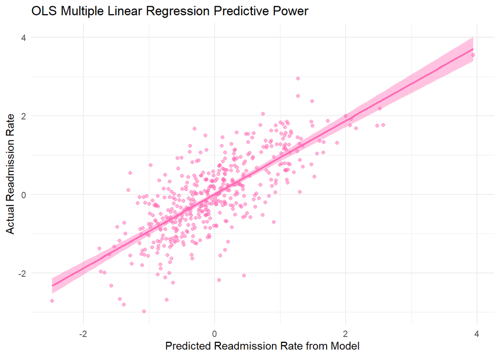

### 4.3 The Elastic Net

A way to extend OLS regression is with the regularized regressions, such as **Ridge**, **LASSO**, and **Elastic Net**, which are more robust to multicollinearity by assessing penalties for non-zero variance. Typically, we would likely conduct a Ridge and/or LASSO before running an Elastic Net, but since we already know that (1) we have a fairly high amount of multicollinearity in our original `readyTrain` dataset and (2) we know we want to be able to perform feature reduction and figure out which features are important predictors of hospital readmissions, we’re going to jump straight into Elastic Net, which can perform both.

#### 4.3.1 The Elastic Net Unpacked

In general, regularization is a technique that applies a penalty term to a cost function of a machine learning model, like the OLS regression. The reason is to discourage overfitting. This penalty term constrains the model’s coefficients, which limits how flexible they are during training. Why?

The more flexible the coefficients, the less likely they will “learn” new data, i.e., the more generalizable they are! Thus, by applying this penalty (constraint), it improves the model’s performance on “unseen” or new data.

As I’ve alluded, Elastic Net regression is a general regularization technique that combines the regularization techniques of Ridge and LASSO to help us perform both feature selection (i.e., significant coefficients) and feature reduction (importance). The elastic net can even help us with the $P >> n$ problem we dealt with in gene expression data, so we could have applied that algorithm there as well!

Elastic net has two regularization terms, called **L1** (or the Lasso regularization term) and **L2** (the Ridge term).

- **L1**: makes some of the coefficients zero, thereby selecting only the most important features (shrinks them to zero). The term often used is that this term **encourages sparsity in the model**.
- **L2**: reduces the coefficients to small but non-zero values, thereby reducing the coefficients of the unimportant features (which we can use to determine significance). It does this by adding a penalty term, , to the cost function of the model, which is proportional to the coefficient squared. This allows us to retain all the features in the model but reduces the overall impact of the non-significant or less-important ones.

Thus, by combining these techniques together, the Elastic Net is balancing feature selection with feature reduction! If you’re interested in reading the original paper on Elastic Net by Zou and Hastie (2005), you can find a free PDF of the paper [here](https://www.stat.purdue.edu/~tlzhang/mathstat/ElasticNet.pdf).

## 4.3.2 Running, tuning, & cross-validating the Elastic Net

The elastic net can be run using the `glmnet` package (which we are accessing via `caret`), and can be cross-validated as random forest and SVM from our last project could be. This is a big improvement over OLS regression, which cannot be tuned. Additionally, the elastic net has **two hyperparameters** that we can tune, $\alpha$ and $\lambda$ (not to be confused with the $\lambda$ from Box-Cox transformation - Greek letters are abundant in statistics!).

We will start by setting our CV parameters just as we did on the last project, using the `trainControl()` function in `caret`.

```r
ctrl <- trainControl(method = "repeatedcv",
                     number = 10,
                     repeats = 5,
                     search = "grid",
                     verboseIter = FALSE)
```

Then, we will fit the model using the `train()` function in `caret`, specifying that we want to perform an elastic net, which will tune the model and perform CV per the specifications in the `trainControl()`.

```r
searchGrid <- expand.grid(.alpha = seq(0, 1, length.out = 10), .lambda = seq(0, 5, length.out = 15))
elasticMod <- train(bc_PredictedReadmissionRate ~ .,
                    data = readyTrain[, -26],
                    method = "glmnet",
                    tuneGrid = searchGrid,
                    trControl = ctrl)
```

```
## Warning in nominalTrainWorkflow(x = x, y = y, wts = weights, info = trainInfo,
## : There were missing values in resampled performance measures.
```

The error we are getting is a result of a resampling issue with column 4, `Death.rate.for.pneumonia.patients`. There are two possible reasons why we might get this warning, the obvious one being that we forgot to drop NAs from the data. However, we can see that there are not any missing values, so that is not the issue:

```r
sum(colSums(is.na(readyTrain)))
```

```
## [1] 0
```

The other reason would be because of failed convergence of the model. Thus, this suggests that our model failed to converge during cross-validation, likely because in some of the folds the predictions have zero variance.

##### **Question 28**: [1 point]

## Ryan C

Explain what exactly we are doing here. Remind yourself of the parameters of the `trainControl()` and `train()` functions, and look up any new ones you do not yet know. Specifically, make sure to address what type of CV and hyperparameter search is being performed, as well as if both the $\alpha$ and $\lambda$ hyperparameters of elastic net are being tuned.

> We are doing a grid search to tune the hyperparameters of the model. We are doing a 10 fold cross validation. We search alpha values from 0 to 1 and lambda values from 0 to 5.

## 4.3.2 Elastic Net Results

Table 7. Results of the Elastic Net Tuning & 10-fold Cross-Validation

| alpha | lambda | RMSE | Rsquared | MAE | RMSESD | RsquaredSD | MAESD |
| --- | --- | --- | --- | --- | --- | --- | --- |
| 0.00 | 0.00 | 0.72 | 0.48 | 0.57 | 0.03 | 0.04 | 0.03 |
| 0.00 | 0.36 | 0.73 | 0.47 | 0.58 | 0.03 | 0.04 | 0.03 |
| 0.00 | 0.71 | 0.74 | 0.46 | 0.59 | 0.03 | 0.04 | 0.03 |
| 0.00 | 1.07 | 0.75 | 0.46 | 0.60 | 0.03 | 0.04 | 0.03 |
| 0.00 | 1.43 | 0.76 | 0.45 | 0.61 | 0.03 | 0.04 | 0.03 |
| 0.00 | 1.79 | 0.77 | 0.44 | 0.61 | 0.04 | 0.05 | 0.03 |
| 0.00 | 2.14 | 0.78 | 0.44 | 0.62 | 0.04 | 0.05 | 0.03 |
| 0.00 | 2.50 | 0.79 | 0.43 | 0.63 | 0.04 | 0.05 | 0.03 |
| 0.00 | 2.86 | 0.80 | 0.43 | 0.63 | 0.04 | 0.05 | 0.03 |
| 0.00 | 3.21 | 0.80 | 0.42 | 0.64 | 0.04 | 0.05 | 0.03 |
| 0.00 | 3.57 | 0.81 | 0.42 | 0.64 | 0.04 | 0.05 | 0.03 |
| 0.00 | 3.93 | 0.81 | 0.42 | 0.65 | 0.04 | 0.05 | 0.03 |
| 0.00 | 4.29 | 0.82 | 0.41 | 0.65 | 0.04 | 0.05 | 0.03 |
| 0.11 | 0.00 | 0.72 | 0.48 | 0.57 | 0.03 | 0.04 | 0.03 |
| 0.11 | 0.36 | 0.74 | 0.47 | 0.59 | 0.03 | 0.04 | 0.03 |
| 0.11 | 0.71 | 0.77 | 0.46 | 0.61 | 0.04 | 0.05 | 0.03 |
| 0.11 | 1.07 | 0.80 | 0.45 | 0.64 | 0.04 | 0.05 | 0.03 |
| 0.22 | 0.00 | 0.72 | 0.48 | 0.57 | 0.03 | 0.04 | 0.03 |
| 0.22 | 0.36 | 0.75 | 0.46 | 0.60 | 0.04 | 0.05 | 0.03 |
| 0.33 | 0.00 | 0.72 | 0.48 | 0.57 | 0.03 | 0.04 | 0.03 |
| 0.33 | 0.36 | 0.77 | 0.46 | 0.61 | 0.04 | 0.05 | 0.03 |
| 0.44 | 0.00 | 0.72 | 0.48 | 0.57 | 0.03 | 0.04 | 0.03 |
| 0.44 | 0.36 | 0.79 | 0.44 | 0.63 | 0.04 | 0.05 | 0.03 |
| 0.44 | 1.07 | 0.98 | 0.32 | 0.78 | 0.04 | 0.06 | 0.03 |
| 0.56 | 0.00 | 0.72 | 0.48 | 0.57 | 0.03 | 0.04 | 0.03 |
| 0.67 | 0.00 | 0.72 | 0.48 | 0.57 | 0.03 | 0.04 | 0.03 |
| 0.67 | 0.71 | 0.97 | 0.31 | 0.77 | 0.04 | 0.06 | 0.03 |
| 0.78 | 0.00 | 0.72 | 0.48 | 0.57 | 0.03 | 0.04 | 0.03 |
| 0.89 | 0.00 | 0.72 | 0.48 | 0.57 | 0.03 | 0.04 | 0.03 |
| 1.00 | 0.00 | 0.72 | 0.48 | 0.57 | 0.03 | 0.04 | 0.03 |

Hmm, I am not seeing that any of the folds failed to converge ($R^2$ = `NA`), although that is still the only other cause for the issue.

#### What were the hyperparameters of our best tuned model?

$\alpha$:

```
## [1] 0.7777778
```

$\lambda$:

```
## [1] 0
```

##### **Question 28**: [1 point]

## Ryan C

Check the values of $\alpha$ and $\lambda$ here. What do they suggest about the optimal regularization that is being fit here? (Recall that when both $\alpha$ and $\lambda$ are zero, it’s an OLS regression!)

Let’s also plot the results of the tuning search. Can you the type of tuning search you did? (**Hint**: the visual pattern should confirm your answer from earlier!)

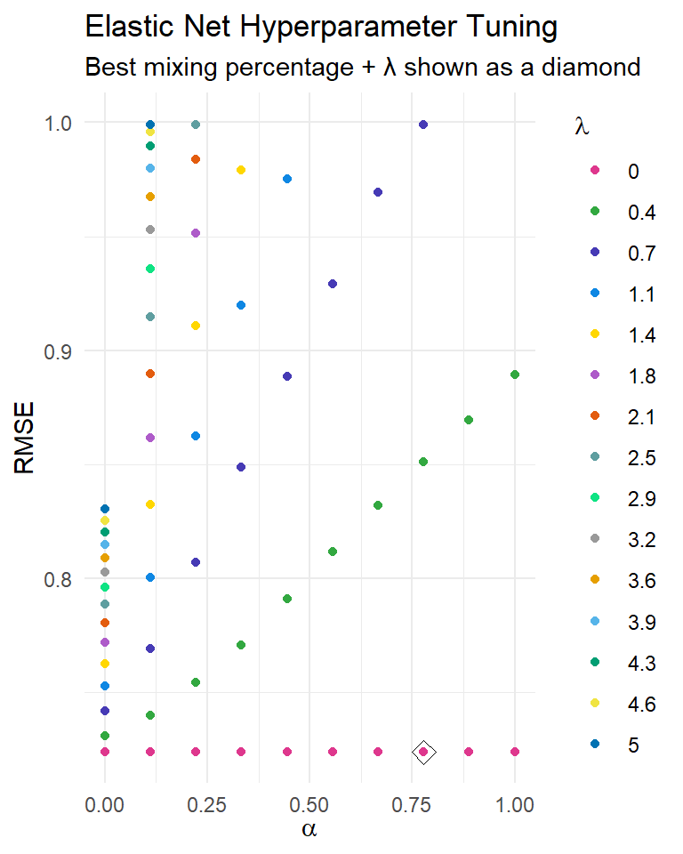

#### Important Features

Important features can also be extracted, using the `varImp()` function from `caret`.

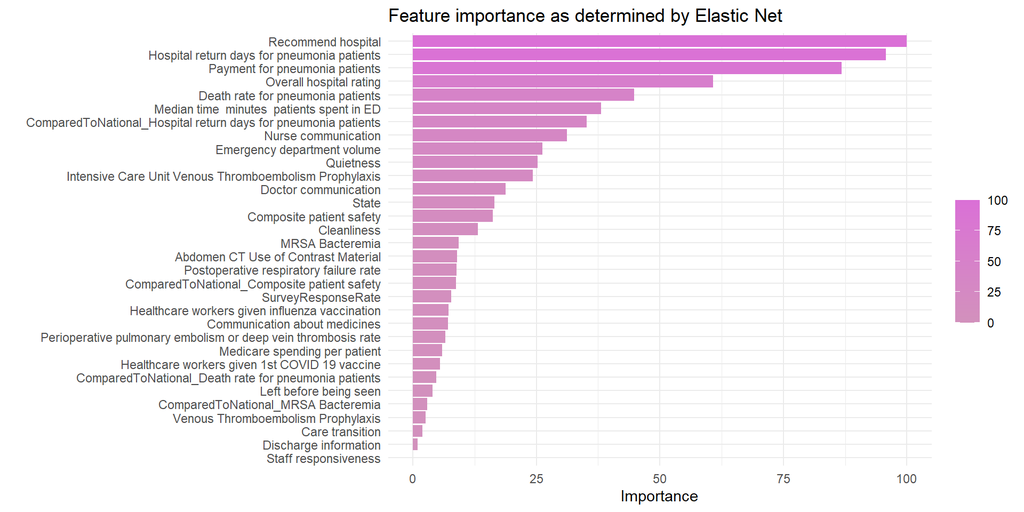

##### **Question 29**: [1 point]

## Ryan C

Which of the features were most important? How does this compare to the most important features out of regression? How about about of PCA?

Let’s also make predictions on the testing sets for the OLS and Elastic Net models using the `postResample()` function in `caret`; this will do predictions, but it will enable us to more easily generate metrics that we can use to compare model performance, such as $R^2$ and MAE.

```r
prOLS <- postResample(pred = predict(mod, newdata = regressionTest),
                      obs = regressionTest$bc_PredictedReadmissionRate)

prElastic <- postResample(pred = predict(elasticMod, newdata = readyTest),
                      obs = readyTest$bc_PredictedReadmissionRate)

## Display the output
rbind(prOLS, prElastic) %>%
  kable(digits = 2,
    format = "html",
    caption = "Table 8. Comparison of the OLS and Elastic Net Regressions") %>%
    kable_styling(bootstrap_options = c("hover", full_width = F)
)
```

Table 8. Comparison of the OLS and Elastic Net Regressions

|  | RMSE | Rsquared | MAE |
| --- | --- | --- | --- |
| prOLS | 0.67 | 0.56 | 0.52 |
| prElastic | 0.77 | 0.41 | 0.61 |

##### **Question 30**: [1 point]

## Ryan C

> For OLS regression the RMSE is lower on training data compared to testing data, R^2 is higher on training data compared to testing data, and the MAE is lower on training data compared to testing data. All of these point towards the model starting to overfit.

> Even thought the model is slightly overfitting the I think the OLS regression preforms better because the values of the RMSE, R-squared, and MAE are closer then the values for the Elastic Net model. Becasue of this when given more data that it has not seen it will do better and be stronger at making predictions.

```r
prOLS_train <- postResample(pred = predict(mod, newdata = readyTrain),
                            obs = readyTrain$bc_PredictedReadmissionRate)
prElastic_train <- postResample(pred = predict(elasticMod, newdata = readyTrain),
                                obs = readyTrain$bc_PredictedReadmissionRate)

rbind(prOLS_train, prOLS, prElastic_train, prElastic) %>%
  kable(digits = 2,
        format = "html",
        caption = "Table 8. Comparison of the OLS and Elastic Net Regressions on Training Data") %>%
  kable_styling(bootstrap_options = c("hover", full_width = F))
```

Table 8. Comparison of the OLS and Elastic Net Regressions on Training Data

|  | RMSE | Rsquared | MAE |
| --- | --- | --- | --- |
| prOLS_train | 0.62 | 0.61 | 0.48 |
| prOLS | 0.67 | 0.56 | 0.52 |
| prElastic_train | 0.71 | 0.49 | 0.56 |
| prElastic | 0.77 | 0.41 | 0.61 |

A graphical comparison of the two models.

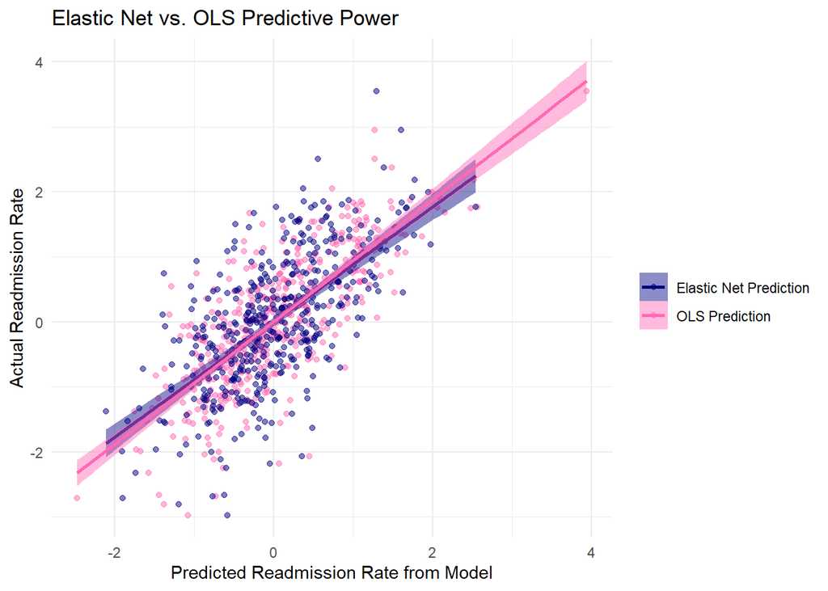

##### **Question 31**: [4 points]

## Ryan C

What conclusions do you make at this point about whether to make predictions with an OLS regression, Elastic Net, or neither? What recommendations would you make to our client at this point? What other analyses might your suggest, or other data we might want to include? Please try to flesh out 2-3 recommendations in at least a paragraph.

At this point, the decision to use predictions from an OLS regression depends on the specific objectives and constraints of the project. Here are some conclusions and recommendations based on the analysis:

> To conclude, the OLS regression model is showing signs of overfitting which can be seen in the table above where the metrics are lower on the testing data compared to the training data. However, it still generally outperforms the Elastic Net model in terms of predictive accuracy on unseen data. Despite the overfitting, the OLS regression model can still provide valuable insights and predictions on paitents with pneumonia-related illnesses. To the clients, I would recommend other regularization techniques like Lasso to try to fix the overfitting problem. By fixing this, this would also improve the performance of the model. We could also explore other optons like trying different ensemble methods like boosting and bagging. Another thing could be looking at how the data was collected so we can improve the model by giving it different or better data. We can update the datasets to add any new or relevant data. We can look at domain-specific variables to see if demographics, medical history, and treatment protocols could provide valuable insights into readmission rates. Finally we can check back in with the paitents at a later time to see if any new patterns emerge that were not there intially. Even though the OLS regression model still has some limitations, it still provideding valuable predictions and insights. If we employ the recommendations above I am confident that the models prediction accuracy will further improve and do a better job at meeting our objectives.

# 5 Next Steps

It’s time to choose your adventure! After working through this demo and answering the 31 questions, you will choose one of three possible trajectories. The following are some brief hints or tips for each of the choices available to you.

## 5.2 Choose your Adventure

#### Adventure 1. [Choosing one other condition to analyze.]

- Make sure that you use the code I provided, updating it for your new condition
- Make sure to answer all of the interpretative questions again for your new dataset.
- I will specifically be looking for a comparison of which condition, pneumonia or the one you chose, seems to be a better choice for a predictive model for our client. Or is it neither?
- Make sure to include some next steps or recommendations based on your new analysis!

#### Adventure 2. [Choosing two or more conditions to analyze.]

- Choose a slightly more complicated analysis to undertake, for example, focusing on surgical interventions (`HIP-KNEE` & `CABG`) or heart-related conditions (`HF`, `AMI`, & `CABG`).
- See the same recommendations and hints as above as above.

#### Adventure 3. [Continue analyzing the pneuomnia data.]

- Make sure to justify your choice.
- Choose at least two new algorithms to perform. They can be unsupervised or supervised, but must be 2+.
- A natural extension would be to do a Ridge and a LASSO. Another option to consider might be a regression-based random forest, since we’ve already done something similar, but you are free to choose anything you think is appropriate here!
- Other choices I think you could easily justify: (1) classification-based random forest using `ComparedToNational_Hospital return days for pneumonia patients`, (2) kNN using the three clusters we’ve identified and named in our segmentation analysis, or (3) an SVM, as the data are already prepared for that as well. And, although they may still be beyond your skillset, our data are also ready for a neural network analysis (e.g., a feed-forward NN)!

## 5.2 Deliverables

Unlike what you may have seen on Canvas, I am going to make things much lighter on you this time so we can all catch a breath. I am looking for 1-2 markdown documents with their knitted HTML. For example, if you’re choosing Adventures 1 or 2, you may want to work through this document once, make a copy, and then do it again for the new condition(s) you choose to work through. If you’re choosing Adventure 3, maybe you just choose to add on to the bottom of this document, replacing the ‘Next Steps’ section you see here.

Just make sure to answer the questions well, and make sure to justify the decisions you make. Tell me WHY you’re choosing the condition(s) you are in Adventures 1 or 2. Tell me WHY you’re doing the analyses you are in Adventure 3. Other than that, make this your own exploratory learning adventure!